# Evaluation of OCR Quality of the Historic Newspaper Archive of the KB

Myriam C. Traub, Jacco van Ossenbruggen, Centrum Wiskunde & Informatica, Information Access research group

21 July, 2015

#### Disclaimer

This page describes work in progress. Please cite only as work in progress. For feedback and questions, please do not hesitate to contact us.

In order allow readers to comprehend how we compiled the numbers and statistics, this document was created using [KnitR](http://yihui.name/knitr/). Therefore, the R code we wrote is included in the document.

For more information about our work, see our paper on [Impact Analysis of OCR Quality on Research Tasks in Digital Archives](http://persistent-identifier.org/?identifier=urn:nbn:nl:ui:18-23429) (TPDL 2015).

# Introduction

The National Library of The Netherlands (KB) is not only reponsible for the collection and preservation of the Dutch cultural heritage, but also for making it accessible. In the [strategic plan 2015-2018](https://www.kb.nl/sites/default/files/docs/strategicplan-2015-2018.pdf), the KB emphasizes the goal of providing a comprehensive and easily accessible platform, not only for the general public, but also for digital humanities scholars.

An interesting resource for historians is the historic newspaper archive, which contains about [one million Dutch newspapers from the period 1618 to 1995](http://www.delpher.nl/nl/platform/pages?title=collecties). It can be searched using full text on the OCR output, and on the meta data attributed to each item in the collection. Despite the fact that it contains copyrighted material, the archive is openly available via the Web. In addition, the library publishes all items in the archive, including the scanned images, the OCRed texts and the metadata records, under a persistent URI scheme. These factors, combined with the large number of pages and the extensive time period covered, make the archive an extremely rich resource that has already been used in many research projects (See lab.kbresearch.nl for examples.).

The quality of the data in an OCRed archive directly influences the performance of tools applied to it, be it search engines or quantitative analysis tools. Therefore, it is important to assess the error rates produced by the OCR engines.

According to our contacts at the KB, no formal evaluation of the OCR quality has been done so far. Therefore, we decided to perform an evaluation for a subset of the archive.

In order to do so, we collected two data sets:

- OCRed textual data from the KB newspaper archive
- ground truth data created by the Impact project

The performance of an OCR engine is largely influenced by the scanned material. Expecially old material often suffers from physical decay, stains, or bleed through of ink. It is also challenging due to unusual layouts and / or fonts that are no longer in use. An example of an OCR error is the “f-s confusion”, see the following example (the entire newspaper page can be found [here](http://resolver.kb.nl/resolve?urn=ddd:010633711:mpeg21:a0010)).

[figure not shown]

The “long s” occurs in historic documents and is mistaken by OCR engines to be an “f”. Therefore, the mention of “Amsterdam” at the beginning of the article is represented as “Amfterdam” in the OCR text.

> ‘t Amfterdam bp Broer lanfz. enbe lacob Pieteriz. Wachter, tjs ©getojucftt feller 350ec6/ Gfjenaetnl Weft-Indiiche Spi-ghd, toaer in men ftett can/ tMJe be «©planben / ©joDtntten / aantfcharpnt/ tet JB.atötigfie Rtjrft Dan Mexico, en ’t©ottt en SHDcr-fitjcfie ïanöt ban Pem. «fampt /©* «Coucfen / «taaenen / flippen/ Coopmanfcjjag’ Setl/ccc. fo toel tn be Noor t aIS tn be Z_yd_r _* .is mebe hoe bic bantoe Spagnaerben eetfl ge tnbaoeert3Ön.©OOl Athanafium ln&$tWRM , ban Cufco,

While this type of error is systematic, as it can be tied to a certain time period (its use declined in the 19th century), most other OCR errors are more random and therefore more difficult to deal with. It is, however, important for humanities scholars to be able to assess the impact of data quality on their research tasks.

[Tool Criticism in the Digital Humanities](http://persistent-identifier.org/?identifier=urn:nbn:nl:ui:18-23500)

# KB OCR Data

In order to compute error rates for the misspellings caused by the OCR engine, we needed a ground truth data set. This is a manually corrected set of texts that we can compare the OCRed texts with.

The ground truth data set we found only covers a small subset of the newspaper archive of the KB. For this, we collected OCR texts provided by the archive.

To download the OCR texts, the following schema can be used:

```
http://resolver.kb.nl/resolve?urn=ddd:[ID]:mpeg21:p[page]:alto
```

**[ID]** = ID of the newspaper in Delpher  
**[page]** = page number of the newspaper page

The data is made available in ALTO XML format, a documentation can be found on the website of the Library of Congress: http://www.loc.gov/standards/alto/.

# IMPACT Ground Truth Data

The ground truth data set was created by the European [IMPACT project](http://www.impact-project.eu/). Unfortunately, it had not been completely finished at the end of the project. Therefore, it had not been used in a formal evaluation of the newspaper OCR quality.

In order to evaluate the quality of the OCR processing of the newspapers, we used this data set to determine the misspellings in the corpus.

```r
options(digits=2)
setwd("~/OCR")
library(prettyR)
library(plyr)
library(ggplot2)
library(XML)
library(stringr)
library(textir)
library(RColorBrewer)
library(vioplot)
library(gplots)
library(corrgram)

# read the concordance file that allows us to match the ground truth files with the IDs in Delpher.nl
concordance <- read.csv("data/impact_concord/Newspapers.csv", sep=";")
# count the number of files
nr_gtfiles <- nrow(concordance)

# extract the ID used in Delpher in order to be able to generate the URL to the ALTO file later
concordance_withID <- concordance[which(concordance$Dmonth != "NULL"),]
concordance_withID$KB_page <- str_sub(concordance_withID$Doriginal, start=-14, end=-12)
concordance_withID$KB_ID <- str_sub(concordance_withID$Doriginal, start=1, end=9)

# add URL of ALTO file
concordance_withID$URL <-   paste("http://resolver.kb.nl/resolve?urn=ddd:", concordance_withID$KB_ID, ":mpeg21:p", concordance_withID$KB_page,":alto", sep = "")

# add URL of the image of the newspaper page
concordance_withID$Image_URL <- paste("http://www.delpher.nl/nl/api/downloadimage?id=ddd%3A", concordance_withID$KB_ID, "%3Ampeg21%3Ap", concordance_withID$KB_page, "%3Aimage&w=2048", sep="")
nr_matchedfiles <- nrow(concordance_withID)
```

The ground truth data set can be downloaded from the [IMPACT website](http://lab.kbresearch.nl/static/html/impact.html). It contains the manually corrected text files for 1024 newspaper pages. The newspaper pages span a timeframe from 1618 to 1885. The number of newspaper pages per year varies strongly, as can be seen here:

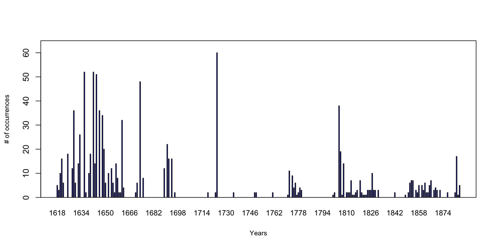

```r
# data frame for storing the counts
counts <- data.frame(min(concordance[,4]):max(concordance[,4]))
names(counts) <- "Dyear"

# calculate the counts of the entire GT data set (all) and the matchable subset (selection)
counts.selection <- as.data.frame(table(concordance_withID$Dyear))
counts.all <- as.data.frame(table(concordance$Dyear))

names(counts.selection) <- c("Dyear", "frequency selection")
names(counts.all) <- c("Dyear", "frequency all")

counts <- merge(x=counts, y=counts.selection, all.x=TRUE)
counts <- merge(x=counts, y=counts.all, all.x=TRUE)
counts[is.na(counts)] <- 0

# plots a barchart with the counts per year for the entire GT data set
x <- barplot(t(counts[,3]),
      names.arg = counts$Dyear, # x-axis labels
      cex.names = 0.9, # makes x-axis labels small enough to show all
      col = "blue", # colors
      xlab = "Years",
      ylab = "# of occurrences",
      ylim = c(0,65),
      width = 0.2,
      cex.lab = 0.8,
      beside = TRUE)
box()
```

Unfortunately, the ground truth files come with a few issues that make them difficult to use:

- Only 265 of the ground truth files can be matched with a newspaper page in the current Delpher archive due to missing IDs.
- The reading order of the paragraphs is not correct.
- Some pages contain duplicate paragraphs.
- Tables are only partially included in the ground truth.
- Text bits that are unreadable for humans, are represented by a EURO character.

Especially the reading order and the duplicate paragraphs had to be corrected in order to be able to use the data.

## Correcting the reading order

In order to correct the reading order, we wrote a script that rearranges the paragraphs according to their position on the page. We ordered the paragraphs with the leftmost coordinates according to their vertical position on the page, followed by the centered paragraphs and the rightmost paragraphs. The re-arranged files were then compared to the text files created by the OCR engine using the *OCRevalUAtion tool* (see https://sites.google.com/site/textdigitisation/home). The coloured errors in the output of the evaluation tool helped to spot misplaced paragraphs.

```r
# create a list of files in the given directory
correct_gtfiles <- list.files("~/OCR/data/KB_groundtruth_correctedRO_dedup/")
```

So far, we have manually corrected 133 files. They serve as the basis for the following analyses. While we did our best to create error-free ground truth files, we cannot guarantee that all misplaced textblocks have been identified and correctly repositioned.

We have corrected the following files (the filenames match the filenames in the original ground truth data set):

```r
print(correct_gtfiles)
```

```
##   [1] "530983.txt" "530986.txt" "530989.txt" "530990.txt" "530991.txt"
##   [6] "530993.txt" "530994.txt" "530995.txt" "530997.txt" "530998.txt"
##  [11] "530999.txt" "531000.txt" "531002.txt" "531003.txt" "531006.txt"
##  [16] "531007.txt" "531008.txt" "531009.txt" "531010.txt" "531011.txt"
##  [21] "531016.txt" "531017.txt" "531020.txt" "531023.txt" "531024.txt"
##  [26] "531031.txt" "531032.txt" "531033.txt" "531034.txt" "531035.txt"
##  [31] "531036.txt" "531039.txt" "531044.txt" "531045.txt" "531046.txt"
##  [36] "531047.txt" "531049.txt" "531052.txt" "531053.txt" "531055.txt"
##  [41] "531056.txt" "531058.txt" "531059.txt" "531060.txt" "531061.txt"
##  [46] "531062.txt" "531063.txt" "531064.txt" "531066.txt" "531068.txt"
##  [51] "531069.txt" "531070.txt" "531071.txt" "531073.txt" "531078.txt"
##  [56] "531080.txt" "531081.txt" "531082.txt" "531084.txt" "531085.txt"
##  [61] "531086.txt" "531088.txt" "531090.txt" "531091.txt" "531092.txt"
##  [66] "531093.txt" "531095.txt" "531097.txt" "531098.txt" "531099.txt"
##  [71] "531105.txt" "531106.txt" "531107.txt" "531108.txt" "531109.txt"
##  [76] "531110.txt" "531115.txt" "531117.txt" "531118.txt" "531119.txt"
##  [81] "531120.txt" "531121.txt" "531123.txt" "531124.txt" "531127.txt"
##  [86] "531130.txt" "531131.txt" "531132.txt" "531133.txt" "531135.txt"
##  [91] "531136.txt" "531137.txt" "531138.txt" "531144.txt" "531149.txt"
##  [96] "531152.txt" "531153.txt" "531156.txt" "531157.txt" "531169.txt"
## [101] "531174.txt" "531175.txt" "531181.txt" "531182.txt" "531186.txt"
## [106] "531187.txt" "531188.txt" "531189.txt" "531193.txt" "531194.txt"
## [111] "531195.txt" "531196.txt" "531199.txt" "531200.txt" "531201.txt"
## [116] "531202.txt" "531207.txt" "531208.txt" "531209.txt" "531218.txt"
## [121] "531219.txt" "531222.txt" "531231.txt" "531232.txt" "531233.txt"
## [126] "531236.txt" "531237.txt" "531240.txt" "531241.txt" "531242.txt"
## [131] "531244.txt" "531245.txt" "531246.txt"
```

# OCRevaluation: Error Rates

As a next step, we looked at the actual error rates we obtained by comparing the ground truth data with the OCRed texts with the OCRevalUAtion tool (see https://github.com/impactcentre/ocrevalUAtion). It takes three types of errors into account: substitutions *(s)*, insertions *(i)* and deletions *(d)*. The output is an HTML page that juxtaposes the two input texts with highlighted errors and tables presenting error rates per character.

The screenshot below shows part of the output for one of our OCR files.

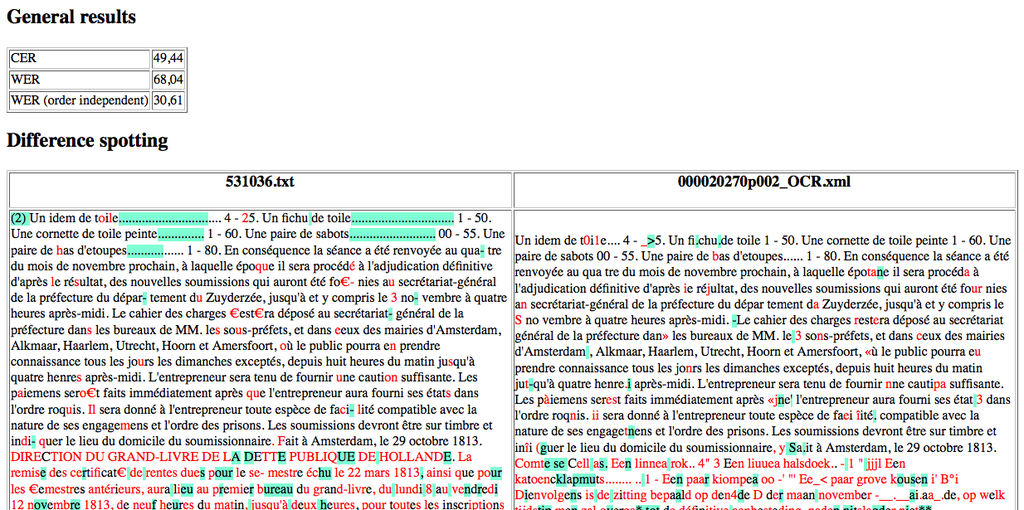

At the top of the result page, error rates per page are given. Below that, a table comparing the ground truth text (left column) with the OCR text (right column). At the bottom of the page, a table with error rates for each character on the page is shown (not on the screenshot).

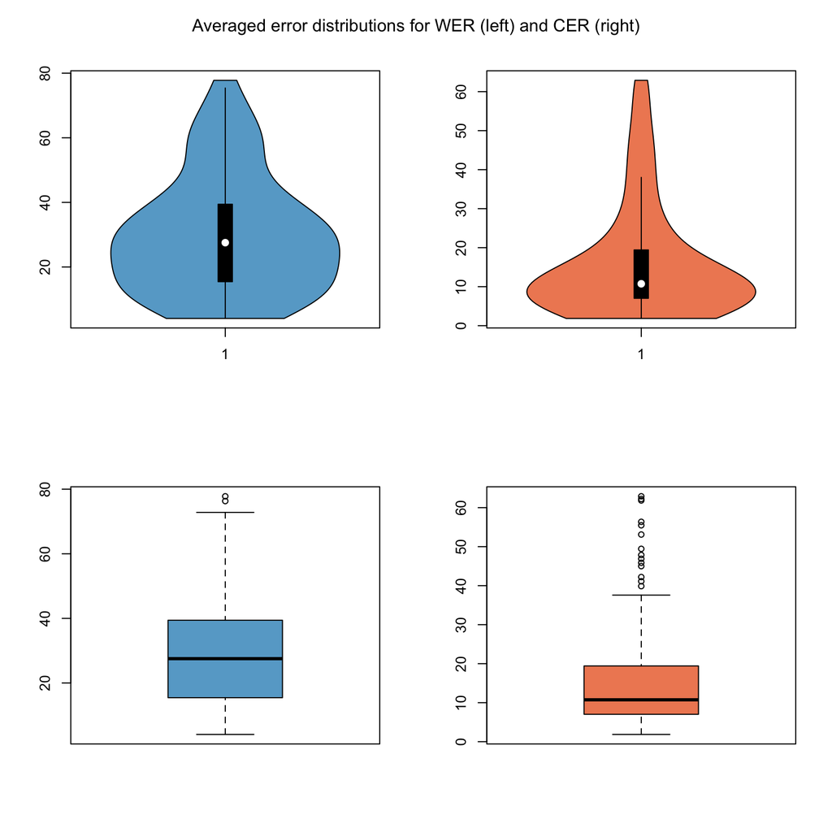

```r
setwd("~/OCR")
path <- "~/OCR/data/OCRevalres_correctedGT/"
errors <- data.frame(GT = character(0), OCR = character(0), WER = numeric(0), CER = numeric(0))
file.ls <- list.files(path)

# extract the error rates for every OCR file
for (i in unique(file.ls))
{
    # read the data from the HTML file produced by OCRevalUAtion
    evalres <- htmlTreeParse(paste(path, i, sep=""), useInternal = TRUE)
    content <- as.data.frame(unlist(xpathApply(evalres, '//td', xmlValue)))
    errors <- rbind(errors, data.frame(content[7,], as.data.frame(content[8,]), as.data.frame(content[4,]), as.data.frame(content[2,])))
}

# rename the columns and replace commas with decimal points
names(errors) <- c("GT", "OCR", "WER", "CER")
errors$WER <- as.numeric(gsub(",",".", errors$WER))
errors$CER <- as.numeric(gsub(",",".", errors$CER))

# calculate correlation between word and character error rates
correlation.wc <- cor(errors[, c("WER", "CER")])

# visualize the error distribution as boxplot and as violin plot
par(mfrow=c(2,2))
vioplot(errors$WER, col="#67a9cf")
vioplot(errors$CER, col="#ef8a62")
boxplot(errors$WER, col="#67a9cf")
boxplot(errors$CER, col="#ef8a62")
mtext("Averaged error distributions for WER (left) and CER (right)", side = 3, line = -2, outer = TRUE)
```

First, we look at the distribution of page level word error rates (*WER*) and character error rates (*CER*). WER are usually higher than CER (see http://www.dlib.org/dlib/july09/munoz/07munoz.html) and show a strong correlation. The correlation between WER and CER values in our data collection is 0.8692243.

The CER is computed based on the Levenshtein distance (see https://gitlab.doc.ic.ac.uk/wm613/inidividual-project/raw/4fbe43f863b229b50ca13bf5f59eb029ad71f6b6/reading/litreview/levenshtein66.pdf) between the reference text and the output text (see http://dl.acm.org/citation.cfm?id=2595221): $CER = \frac{i+s+d}{n}$ It is possible, that the error rate exceeds 100%.

The WER is computed similarly: $WER = \frac{i_w + s_w +d_w}{n_w}$

The WER of the OCR files ranges between 4.07 and 77.8, with a mean of 30.0743609, median of 27.53 and a standard deviation of 18.2032023.

The CER of the OCR files ranges between 1.86 and 62.91, with a mean of 16.0054135, median of 10.74 and a standard deviation of 14.5376394.

The following figure shows how the error rates vary over time:

```r
# add the full file name to the concordance table
concordance_withID$GT <- paste(concordance_withID$Did, ".txt", sep="")
errors$GT <- str_sub(errors$GT, start=1, end=12)
errors$GT <- gsub("[^.0-9tx///' ]", "", errors$GT)

# merge the concordante file with error rates into a new data frame
errors.time <- merge(errors, concordance_withID[,c("Dyear", "GT")],all.x=TRUE, by="GT")
errors.time <- errors.time[order(errors.time$Dyear),]
```

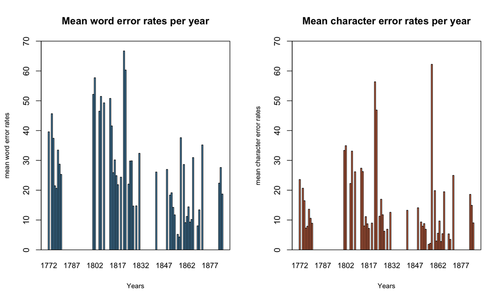

```r
setwd("~/OCR")
mean.error <- data.frame( min(errors.time[,5]):max(errors.time[,5]))
names(mean.error) <- "Dyear"
mean.error$meanWER <- NA
mean.error$meanCER <- NA

# calculate the mean error rate for each year
for (i in unique(errors.time$Dyear))
{
  mean.error$meanWER[mean.error$Dyear == i] <- mean(errors.time$WER[errors.time$Dyear==i])
  mean.error$meanCER[mean.error$Dyear == i] <- mean(errors.time$CER[errors.time$Dyear==i])
}
par(mfrow=c(1,2))
#sequential <- c("blue","chartreuse3")

# visualize the mean error rate per year for word errors
WERplot <- barplot(mean.error$meanWER,
       names.arg = mean.error$Dyear, # x-axis labels
       # names.arg = plot.data$start_year, # x-axis labels
       cex.names = 0.9, # makes x-axis labels small enough to show all
       col = "#67a9cf", # colors
       xlab = "Years",
       ylab = "mean word error rates",
       ylim = c(0,70),
       width = 0.8,
       cex.lab = 0.8,
       main = "Mean word error rates per year",
       beside = TRUE)
box()

# visualize the mean error rate per year for character errors
CERPlot <- barplot(mean.error$meanCER,
       names.arg = mean.error$Dyear, # x-axis labels
       # names.arg = plot.data$start_year, # x-axis labels
       cex.names = 0.9, # makes x-axis labels small enough to show all
       col = "#ef8a62", # colors
       xlab = "Years",
       ylab = "mean character error rates",
       ylim = c(0,70),
       width = 0.8,
       cex.lab = 0.8,
       main = "Mean character error rates per year",
       beside = TRUE)
box()
```

```r
# print the data of the plots
print(mean.error)
```

```
##     Dyear  meanWER   meanCER
## 1    1772 39.59167 23.593333
## 2    1773       NA        NA
## 3    1774 45.66000 20.665000
## 4    1775 37.40750 16.480000
## 5    1776 21.48000  7.300000
## 6    1777 20.63000  7.930000
## 7    1778 33.46000 13.640000
## 8    1779 28.74000 10.590000
## 9    1780 25.31333  8.936667
## 10   1781       NA        NA
## 11   1782       NA        NA
## 12   1783       NA        NA
## 13   1784       NA        NA
## 14   1785       NA        NA
```

[output cut: 100 more lines]

# Conclusions

We have analyzed the accuracy of OCRed text that originates from digitized newspaper pages from the historic newspaper archive of the National Library of The Netherlands. Our analysis shows that the quality of the OCRed text varies strongly.

The question, what OCR accuracy could be considered “acceptable”, is difficult to answer. Holley classified OCR accuracy as follows (see http://www.dlib.org/dlib/march09/holley/03holley.html):

```
Good OCR accuracy       = 98-99% accurate       (1-2% of OCR incorrect)
Average OCR accuracy     = 90-98% accurate      (2-10% of OCR incorrect)
Poor OCR accuracy       = below 90% accurate    (more than 10% of OCR incorrect)
```

By matching our results into these categories, we see that 2.2556391% (3) of the evaluated newspaper pages can be rated as “good”, 44.3609023% (59) as “average” and 53.3834586% (71) must be seen as “poor”.

A considerable part of the collection of newspaper pages we have collected, is of poor quality. This affects readability as well as searchability of the OCR texts. To what extent this affects research tasks performed on this data depends strongly on the requirements of the task and will be part of our future work.

# Acknowledgement

We would like to thank the staff of the National Library of The Netherlands and the IMPACT project for their support and fruitful discussions. This work is funded by the Dutch COMMIT/ program.